# Hotspot

Liangxiao LI

2023-07-18

## Load library

Parameter change: at row 405，row 776 (aplha)

## Load data

Load data with spatial coordinates and mutation rates

## Prove necessary to do normalise

```
##        X               Y               Z          virusPercent
##  Min.   :167.2   Min.   :176.5   Min.   :117.6   Min.   :0.0000100
##  1st Qu.:184.9   1st Qu.:209.8   1st Qu.:179.0   1st Qu.:0.0000991
##  Median :196.7   Median :223.2   Median :213.9   Median :0.0002008
##  Mean   :197.9   Mean   :223.4   Mean   :206.7   Mean   :0.0148854
##  3rd Qu.:210.0   3rd Qu.:237.3   3rd Qu.:235.7   3rd Qu.:0.0005884
##  Max.   :231.3   Max.   :270.4   Max.   :273.4   Max.   :0.9894060
```

##Some plots

##Prove necessary to do normalization

Method 1 : 2 sample t test

Caculate each dimension’s mean and standard error

mean

```
##            X            Y            Z virusPercent
## 197.90096296 223.42346296 206.70969547   0.01488539
```

```r
apply(sub_data,2,sd)
```

```
##            X            Y            Z virusPercent
##  15.66273771  19.35188134  35.64056830   0.07951385
```

H0 : equal mean H1 : not equal mean

if p-value small, then 2 covariates has significant difference between mean, which means it requires normalization.(scale)

```
##
##  Welch Two Sample t-test
##
## data:  sub_data[, 1] and sub_data[, 2]
## t = -31.961, df = 1861.2, p-value < 2.2e-16
## alternative hypothesis: true difference in means is not equal to 0
## 95 percent confidence interval:
##  -27.08863 -23.95637
## sample estimates:
## mean of x mean of y
##  197.9010  223.4235
```

```
##
##  Welch Two Sample t-test
##
## data:  sub_data[, 1] and sub_data[, 3]
## t = -7.0544, df = 1332.6, p-value = 2.778e-12
## alternative hypothesis: true difference in means is not equal to 0
## 95 percent confidence interval:
##  -11.258347  -6.359118
## sample estimates:
## mean of x mean of y
##  197.9010  206.7097
```

```
##
##  Welch Two Sample t-test
##
## data:  sub_data[, 2] and sub_data[, 3]
## t = 12.849, df = 1497.8, p-value < 2.2e-16
## alternative hypothesis: true difference in means is not equal to 0
## 95 percent confidence interval:
##  14.16215 19.26538
## sample estimates:
## mean of x mean of y
##  223.4235  206.7097
```

Method 2: correlation analysis

```
##               X             Y          Z
## X  1.000000e+00  1.541822e-05 -0.2822801
## Y  1.541822e-05  1.000000e+00 -0.1088545
## Z -2.822801e-01 -1.088545e-01  1.0000000
```

```
## correlation between X and Y is 1.541822e-05 with p-value 0.999617
## correlation between X and Z is -0.2822801 with p-value 2.901489e-19
## correlation between Y and Z is -0.1088545 with p-value 0.0006751244
```

```
##              X            Y           Z
## X  1.000000000  0.007963602 -0.16908473
## Y  0.007963602  1.000000000 -0.07584046
## Z -0.169084731 -0.075840461  1.00000000
```

```
## correlation between X and Y is 0.007963602 with p-value 0.7100832
## correlation between X and Z is -0.1690847 with p-value 2.950326e-15
## correlation between Y and Z is -0.07584046 with p-value 0.000399708
```

Therefore, we need to do normalization

#Normalization validation

It’s able to normalize if the data follows same distribution before and after the normalization.

First normalise x,y,z

```r
#抽提坐标数据
xyz<-data2[,c("X","Y","Z")]
#标准化xyz数据
xyz_norm<-scale(xyz)
# 将标准化处理过的坐标和突变频率组合为特征向量
feature_vector <- cbind(xyz_norm, data2$virusPercent)

data2 <- data.frame(data2)
```

```r
plot3d(feature_vector[,1], feature_vector[,2], feature_vector[,3], col = "blue", size = 2)
plot3d(data2[,1], data2[,2], data2[,3], col = "blue", size = 2)
```

```r
#原始的xyz和标准化后的xyz的数据范围和分布
# 查看原始数据的数据范围和分布情况
summary(data2[, 1:3])  # 显示前三列（x、y、z）的数据范围和分布情况
```

```
##        X               Y               Z
##  Min.   :167.2   Min.   :176.5   Min.   :117.6
##  1st Qu.:184.9   1st Qu.:209.8   1st Qu.:179.0
##  Median :196.7   Median :223.2   Median :213.9
##  Mean   :197.9   Mean   :223.4   Mean   :206.7
##  3rd Qu.:210.0   3rd Qu.:237.3   3rd Qu.:235.7
##  Max.   :231.3   Max.   :270.4   Max.   :273.4
```

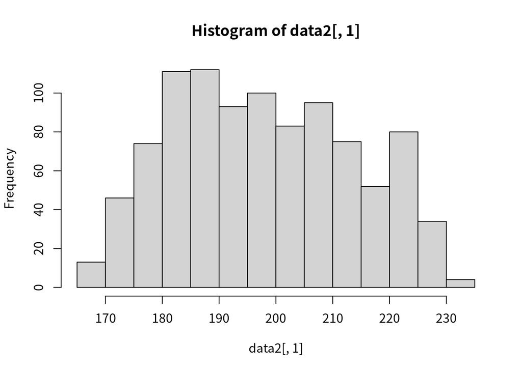

```r
hist(data2[, 1])      # 绘制x列的直方图
```

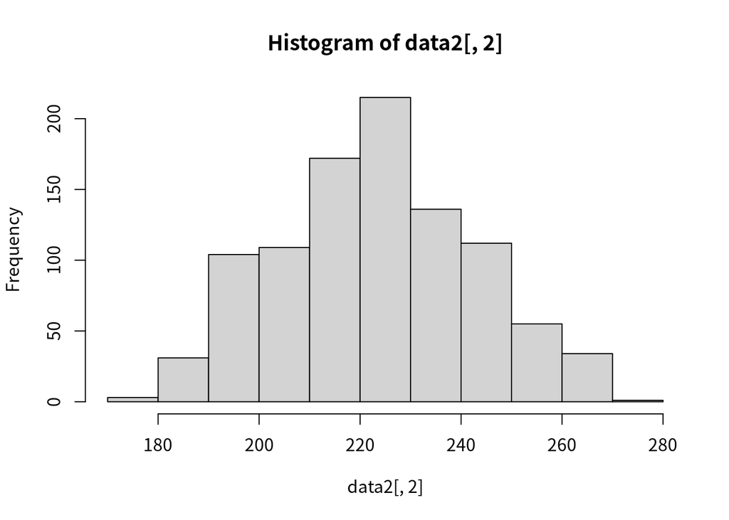

```r
hist(data2[, 2])      # 绘制y列的直方图
```

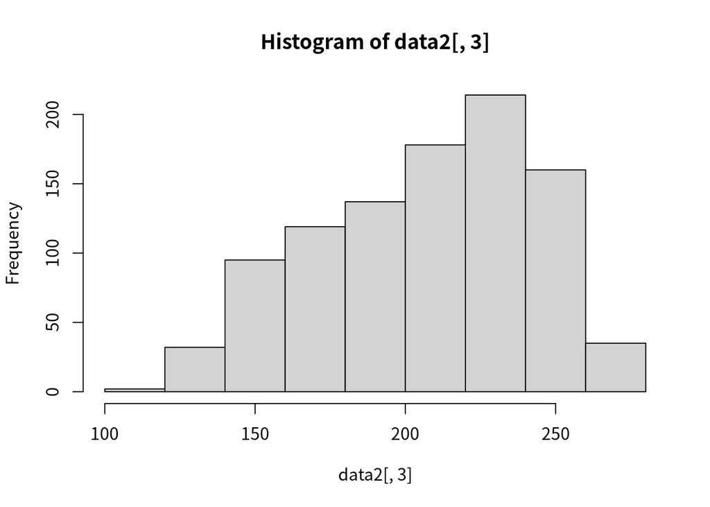

```r
hist(data2[, 3])      # 绘制z列的直方图
```

```r
# 查看标准化后的数据的数据范围和分布情况
summary(feature_vector[, 1:3])  # 显示前三列（x_norm、y_norm、z_norm）的数据范围和分布情况
```

```
##        X                  Y                   Z
##  Min.   :-1.95821   Min.   :-2.426661   Min.   :-2.5007
##  1st Qu.:-0.83055   1st Qu.:-0.705498   1st Qu.:-0.7779
##  Median :-0.07415   Median :-0.009377   Median : 0.2008
##  Mean   : 0.00000   Mean   : 0.000000   Mean   : 0.0000
##  3rd Qu.: 0.77535   3rd Qu.: 0.714803   3rd Qu.: 0.8141
##  Max.   : 2.13405   Max.   : 2.427182   Max.   : 1.8705
```

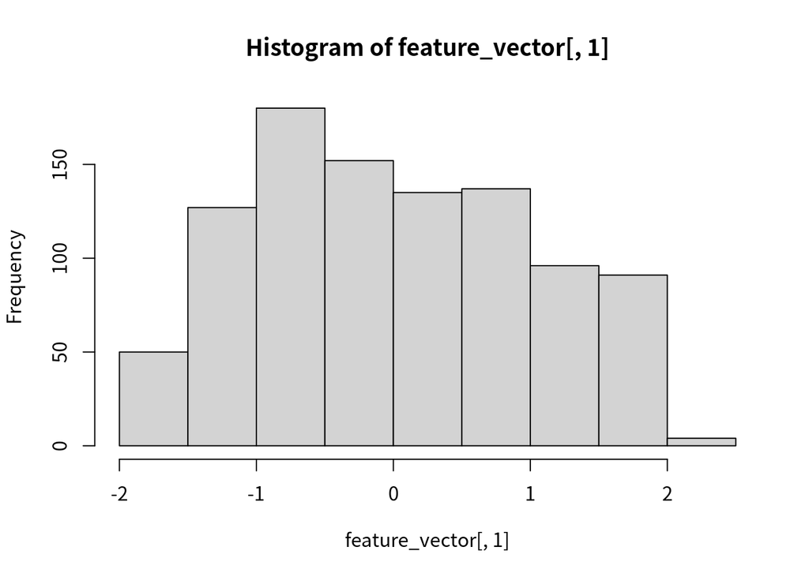

```r
hist(feature_vector[, 1])      # 绘制x_norm列的直方图
```

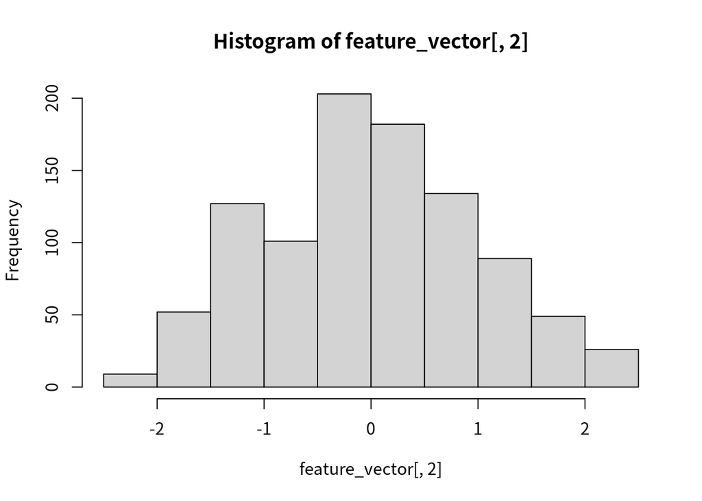

```r
hist(feature_vector[, 2])      # 绘制y_norm列的直方图
```

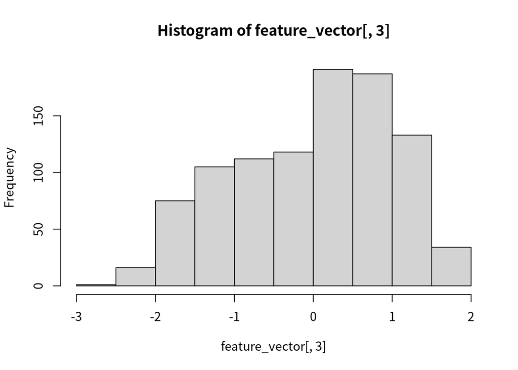

```r
hist(feature_vector[, 3])      # 绘制z_norm列的直方图
```

```r
# 对比前后x列数据的分布
ks.test(data2[, 1], feature_vector[, 1])  # 进行Kolmogorov-Smirnov检验，比较x列的分布
```

```
##
##  Asymptotic two-sample Kolmogorov-Smirnov test
##
## data:  data2[, 1] and feature_vector[, 1]
## D = 1, p-value < 2.2e-16
## alternative hypothesis: two-sided
```

```r
# 对比前后y列数据的分布
ks.test(data2[, 2], feature_vector[, 2])  # 进行Kolmogorov-Smirnov检验，比较y列的分布
```

```
##
##  Asymptotic two-sample Kolmogorov-Smirnov test
##
## data:  data2[, 2] and feature_vector[, 2]
## D = 1, p-value < 2.2e-16
## alternative hypothesis: two-sided
```

```r
# 对比前后z列数据的分布
ks.test(data2[, 3], feature_vector[, 3])  # 进行Kolmogorov-Smirnov检验，比较z列的分布
```

```
##
##  Asymptotic two-sample Kolmogorov-Smirnov test
##
## data:  data2[, 3] and feature_vector[, 3]
## D = 1, p-value < 2.2e-16
## alternative hypothesis: two-sided
```

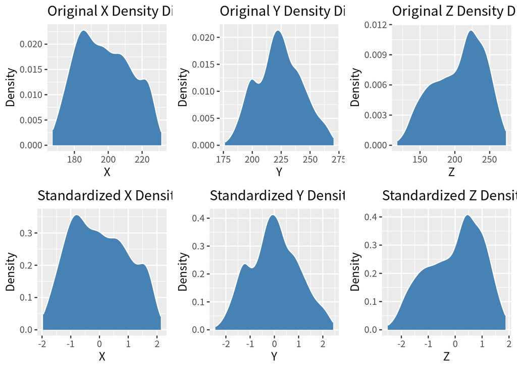

```r
# 原始数据的密度图
p1 <- ggplot(data2, aes(x = X)) +
  geom_density(fill = "steelblue", color = "white") +
  xlab("X") + ylab("Density") + ggtitle("Original X Density Distribution")

p2 <- ggplot(data2, aes(x = Y)) +
  geom_density(fill = "steelblue", color = "white") +
  xlab("Y") + ylab("Density") + ggtitle("Original Y Density Distribution")

p3 <- ggplot(data2, aes(x = Z)) +
  geom_density(fill = "steelblue", color = "white") +
  xlab("Z") + ylab("Density") + ggtitle("Original Z Density Distribution")
feature_vector<-data.frame(feature_vector)
# 标准化后的密度图
p4 <- ggplot(feature_vector, aes(x = X)) +
  geom_density(fill = "steelblue", color = "white") +
  xlab("X") + ylab("Density") + ggtitle("Standardized X Density Distribution")

p5 <- ggplot(feature_vector, aes(x = Y)) +
  geom_density(fill = "steelblue", color = "white") +
  xlab("Y") + ylab("Density") + ggtitle("Standardized Y Density Distribution")

p6 <- ggplot(feature_vector, aes(x = Z)) +
  geom_density(fill = "steelblue", color = "white") +
  xlab("Z") + ylab("Density") + ggtitle("Standardized Z Density Distribution")

# 将六张图合并为两行三列,形状，位置，峰度和偏度
grid.arrange(p1, p2, p3, p4, p5, p6, nrow = 2, ncol = 3)
```

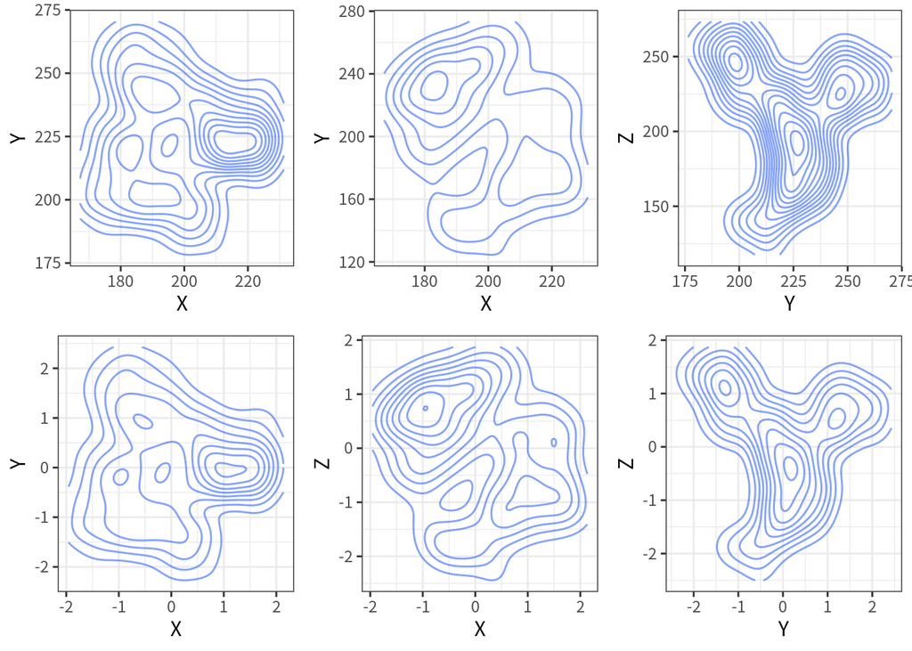

```r
# 循环绘制所有的二维多变量密度图
# 标准化前的二维密度图
library(ggplot2)
p1 <- ggplot(data2, aes(X, Y)) +
  geom_density_2d(alpha = 0.6) +
  labs(x = "X", y = "Y") +
  theme_bw()

p2 <- ggplot(data2, aes(X, Z)) +
  geom_density_2d(alpha = 0.6) +
  labs(x = "X", y = "Y") +
  theme_bw()

p3 <- ggplot(data2, aes(Y, Z)) +
  geom_density_2d(alpha = 0.6) +
  labs(x = "Y", y = "Z") +
  theme_bw()
#标准化后的二维变量密度图
p4 <- ggplot(feature_vector, aes(X, Y)) +
  geom_density_2d(alpha = 0.6) +
  labs(x = "X", y = "Y") +
  theme_bw()

p5 <- ggplot(feature_vector, aes(X, Z)) +
  geom_density_2d(alpha = 0.6) +
  labs(x = "X", y = "Z") +
  theme_bw()

p6 <- ggplot(feature_vector, aes(Y, Z)) +
  geom_density_2d(alpha = 0.6) +
  labs(x = "Y", y = "Z") +
  theme_bw()

# 将六张图合并为两行三列,形状，位置，峰度和偏度
grid.arrange(p1, p2, p3, p4, p5, p6, nrow = 2, ncol = 3)
```

Transformation method 1:

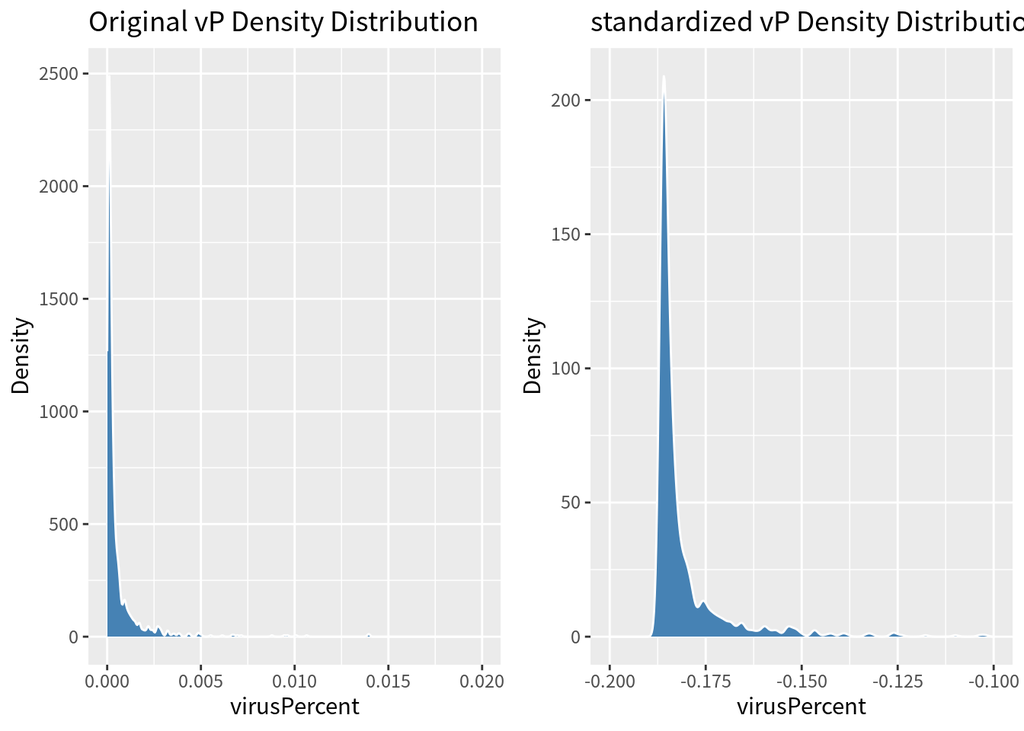

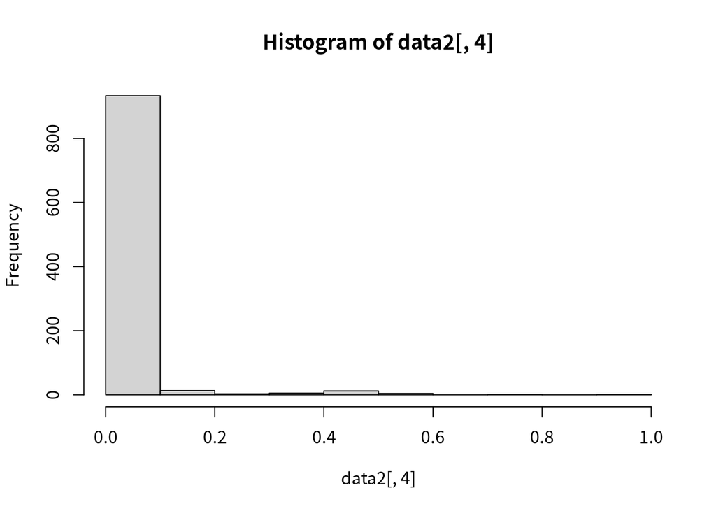

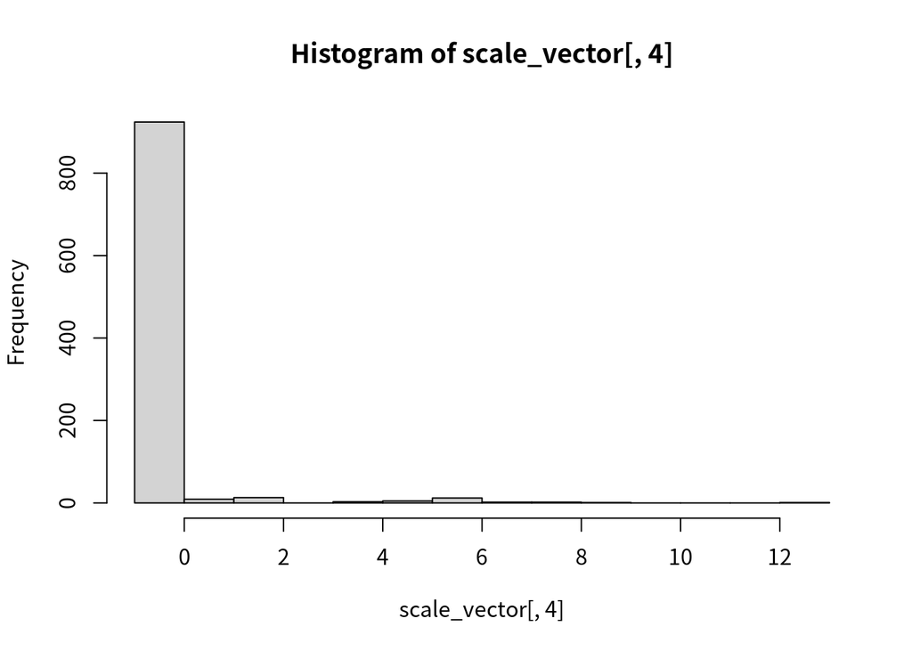

```
##
##  Asymptotic two-sample Kolmogorov-Smirnov test
##
## data:  data2[, 4] and scale_vector[, 4]
## D = 0.95062, p-value < 2.2e-16
## alternative hypothesis: two-sided
```

Transformation Method 2:

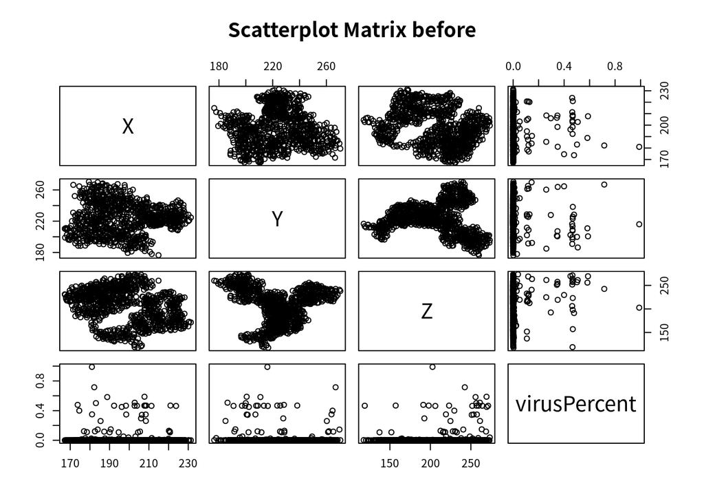

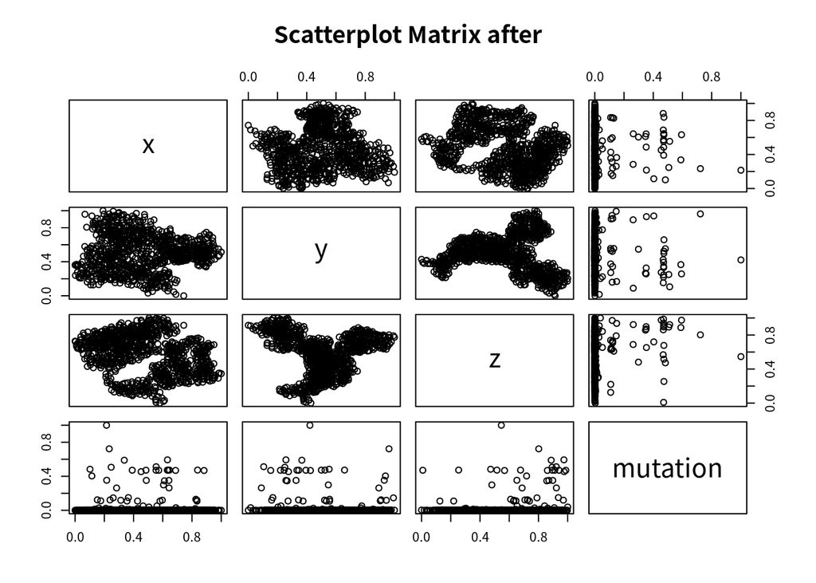

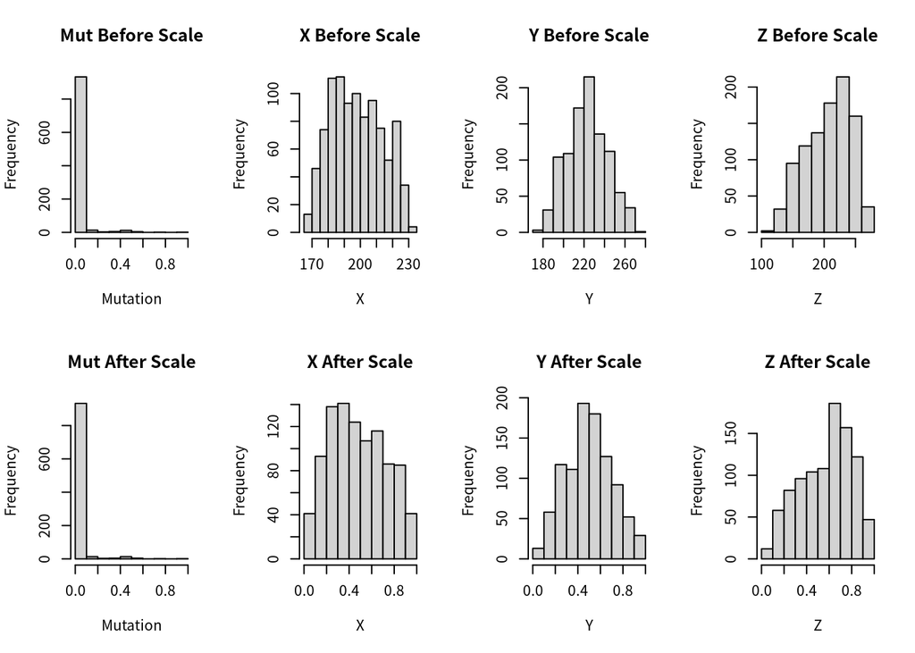

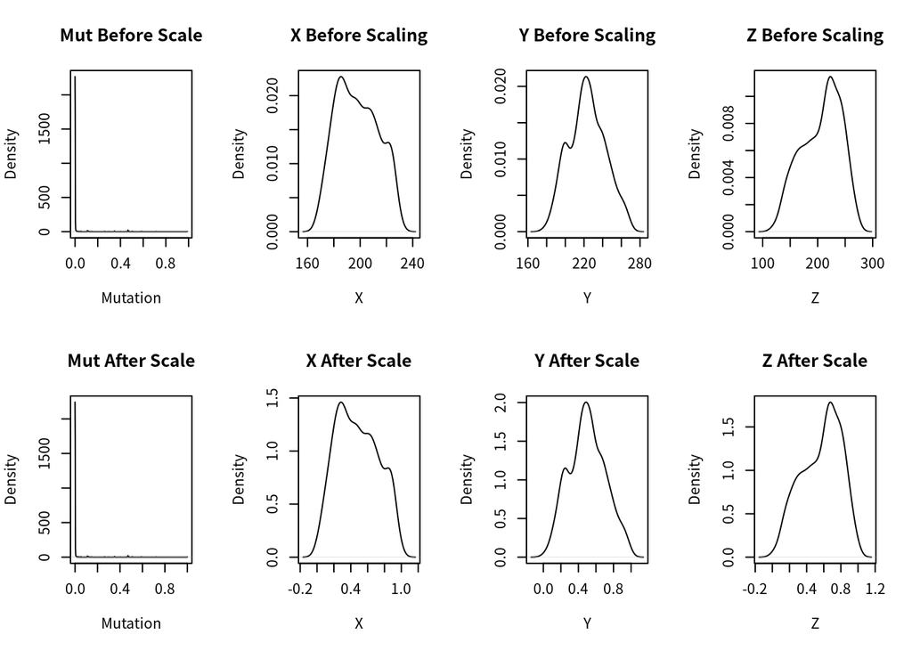

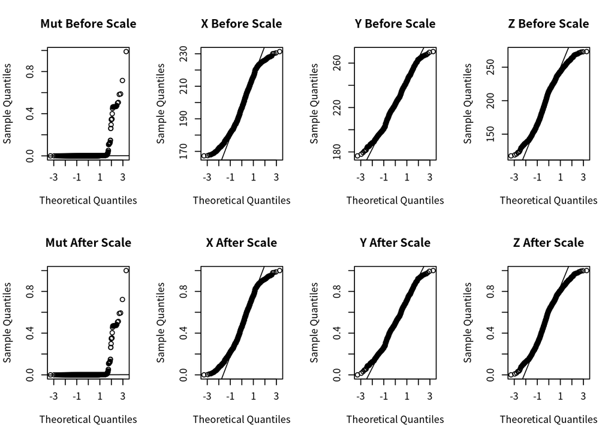

#K-means cluster

Clustering - Model validation (Find best parameter)

```r
#Model validation - find best parameter
index <- data.frame()

#标记最大几个值
topnum = 20

#K-num iteration
Kmin <- 10
Kmax <- 180
iteration <- 20 #iteration number per k num

for (i in Kmin:Kmax) {

  #nstart = 20 means perform k = i for 20 times and select the best cluster outcome among them
  kmeans_result <- kmeans(new_data, centers = i, nstart = iteration)

  wss <- sum(kmeans_result$withinss)

  km_stats <- cluster.stats(dist(data2),  kmeans_result$cluster)

  # Dunn index
  dunn <- km_stats$dunn
  # Calinski-Harabasz index
  ch <- km_stats$ch
  # Average silhouette width
  sil <- km_stats$avg.silwidth
  #Entropy index
  ent <- km_stats$entropy



  # number of noise points :Noise points are data points that do not belong to any specific cluster or are considered outliers
  km_stats$noisen
  # vector of clusterwise within cluster average distances. (这个是scaled version的average distance， non-scaled version到时候还得再算一下)
  km_stats$average.distance
  # Calculate the separation matrix. provides a summary of the between-cluster distances and can help identify clusters that are well-separated or overlapping.
  #The separation matrix is a symmetric matrix that quantifies the degree of separation between clusters based on some distance measure.
  separation_matrix <- km_stats$separation.matrix

  index <- rbind(index, c(dunn, ch, sil, ent,wss))

  }
```

```r
colnames(index) <- c("Dunn", "Calinski-Harabasz", "Average_Silhouette_Width", "Entropy","Wss")

#par(mfrow = c(2, 2))

# Line chart for Dunn Index
plot(index$Dunn, type = "l", xlab = "Observation", ylab = "Dunn Index", main = "Dunn Index",xlim = c(0, length(index$Dunn) +1), ylim = c(min(index$Dunn)*0.95, max(index$Dunn)*1.2 ))

#创建表
top_dun <- data.frame()

# 标记最大值，并加进表里
sorted <- sort(index$Dunn, decreasing = TRUE)
top_three <- head(sorted, topnum)

print(top_three)
```

```
##  [1] 0.1469761 0.1204593 0.1204387 0.1202495 0.1202495 0.1202495 0.1202495
##  [8] 0.1202495 0.1200399 0.1200399 0.1200399 0.1200399 0.1200399 0.1200399
## [15] 0.1200399 0.1200399 0.1200399 0.1199624 0.1199624 0.1199624
```

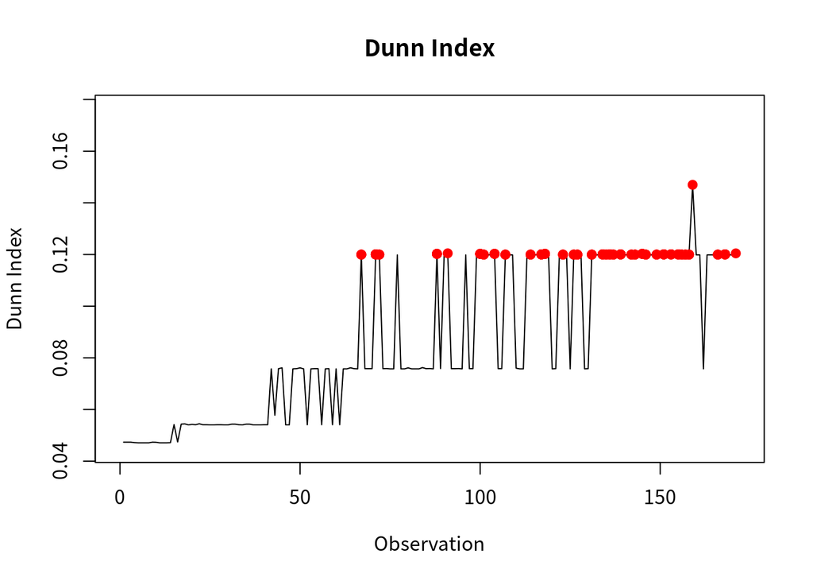

```r
for (i in 1:length(top_three)) {

  num <- which(index$Dunn == top_three[i])
  #text(x = num, y = top_three[i]*1.05, labels = paste0("T", i, ": ", round(top_three[i],5)), offset = 1)

  for (n in num){
    points(x = n, y= top_three[i], col = "red", pch = 19)
  }

  top_dun <- rbind(top_dun, c(i,top_three[i]) )
}
```

```r
colnames(top_dun) <- c("K-Num", "Dunn")
datatable(top_dun)
```

|  | K-Num | Dunn |
| --- | --- | --- |
| 1 | 1 | 0.1469761028923943 |
| 2 | 2 | 0.1204592662630074 |
| 3 | 3 | 0.1204386867227635 |
| 4 | 4 | 0.120249474497455 |
| 5 | 5 | 0.120249474497455 |
| 6 | 6 | 0.120249474497455 |
| 7 | 7 | 0.120249474497455 |
| 8 | 8 | 0.120249474497455 |
| 9 | 9 | 0.1200398948361423 |
| 10 | 10 | 0.1200398948361423 |

[output cut: 10 more lines]

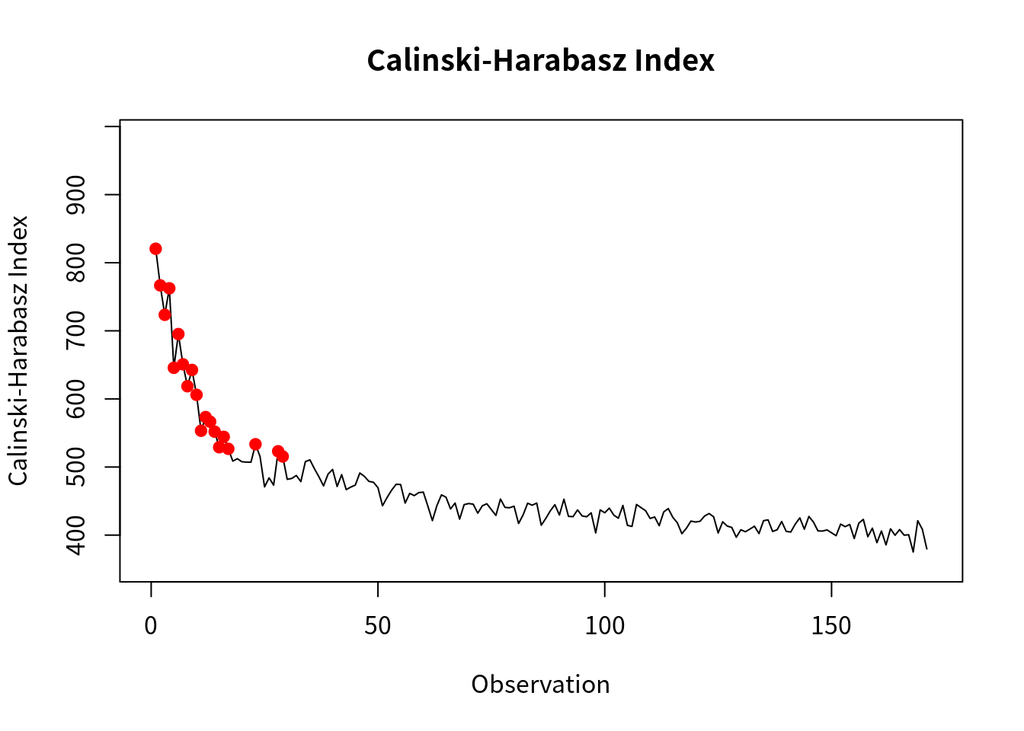

```r
# Line chart for Calinski-Harabasz Index
plot(index$`Calinski-Harabasz`, type = "l", xlab = "Observation", ylab = "Calinski-Harabasz Index", main = "Calinski-Harabasz Index",xlim = c(0, length(index$`Calinski-Harabasz`) +1), ylim = c(min(index$`Calinski-Harabasz`)*0.95, max(index$`Calinski-Harabasz`)*1.2 ))

#创建表
top_ch <- data.frame()

# 标记最大值
sorted <- sort(index$`Calinski-Harabasz`, decreasing = TRUE)
top_three <- head(sorted, topnum)

for (i in 1:length(top_three)) {
  num <- which(index$`Calinski-Harabasz` == top_three[i])
  #text(x = num, y = top_three[i]*1.05, labels = paste0("T", i, ": ", round(top_three[i],5)), offset = 1)

  for (n in num){
    points(x = n, y= top_three[i], col = "red", pch = 19)
  }
  top_ch <- rbind(top_ch, c(num,top_three[i]) )
}
```

```r
colnames(top_ch) <- c("K-Num", "CH")
datatable(top_ch)
```

|  | K-Num | CH |
| --- | --- | --- |
| 1 | 1 | 820.5014023809629 |
| 2 | 2 | 766.7073405193036 |
| 3 | 4 | 762.4209367816507 |
| 4 | 3 | 723.4944254831047 |
| 5 | 6 | 695.2175136210595 |
| 6 | 7 | 650.8135437817936 |
| 7 | 5 | 645.6903571692137 |
| 8 | 9 | 642.5265895175255 |
| 9 | 8 | 618.5918025137706 |
| 10 | 10 | 606.0288869539293 |

[output cut: 10 more lines]

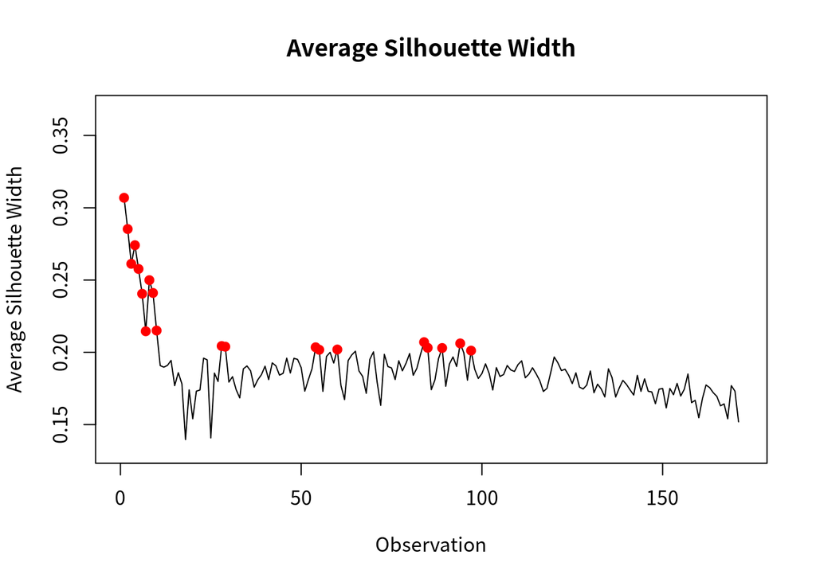

```r
# Line chart for Average Silhouette Width
plot(index$`Average_Silhouette_Width`, type = "l", xlab = "Observation", ylab = "Average Silhouette Width", main = "Average Silhouette Width",xlim = c(0, length(index$`Average_Silhouette_Width`) +1), ylim = c(min(index$`Average_Silhouette_Width`)*0.95, max(index$`Average_Silhouette_Width`)*1.2))

#创建表
top_ASW <- data.frame()

# 标记最大值
sorted <- sort(index$`Average_Silhouette_Width`, decreasing = TRUE)
top_three <- head(sorted, topnum)

for (i in 1:length(top_three)) {
  num <- which(index$`Average_Silhouette_Width` == top_three[i])
  #text(x = num, y = top_three[i]*1.05, labels = paste0("T", i, ": ", round(top_three[i],5)), offset = 1)

  for (n in num){
    points(x = n, y= top_three[i], col = "red", pch = 19)
  }
  top_ASW <- rbind(top_ASW, c(num,top_three[i]) )
}
```

```r
colnames(top_ASW) <- c("K-Num", "CH")
datatable(top_ASW)
```

|  | K-Num | CH |
| --- | --- | --- |
| 1 | 1 | 0.3068986209765913 |
| 2 | 2 | 0.2852944279305583 |
| 3 | 4 | 0.2740994796076032 |
| 4 | 3 | 0.2612226404166412 |
| 5 | 5 | 0.2576765702812594 |
| 6 | 8 | 0.2499325094758984 |
| 7 | 9 | 0.241068606415108 |
| 8 | 6 | 0.2405197879198992 |
| 9 | 10 | 0.2150624054347237 |
| 10 | 7 | 0.2145712302567659 |

[output cut: 10 more lines]

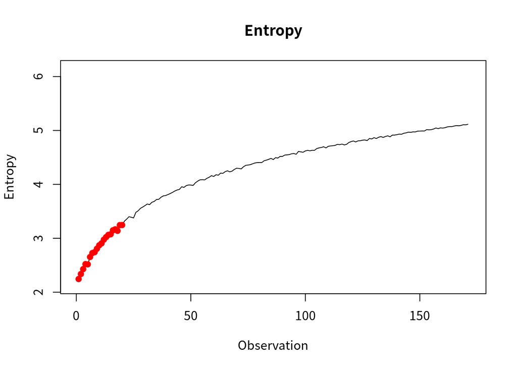

```r
# Line chart for Entropy
plot(index$Entropy, type = "l", xlab = "Observation", ylab = "Entropy", main = "Entropy",xlim = c(0, length(index$Entropy) +1), ylim = c(min(index$Entropy)*0.95, max(index$Entropy)*1.2))


# 标记最大值
sorted <- sort(index$Entropy, decreasing = FALSE)
top_three <- head(sorted, topnum)

for (i in 1:length(top_three)) {
  num <- which(index$Entropy == top_three[i])
  #text(x = num, y = top_three[i]*1.05, labels = paste0("T", i, ": ", round(top_three[i],5)), offset = 1)

  for (n in num){
    points(x = n, y= top_three[i], col = "red", pch = 19)
  }
}
```

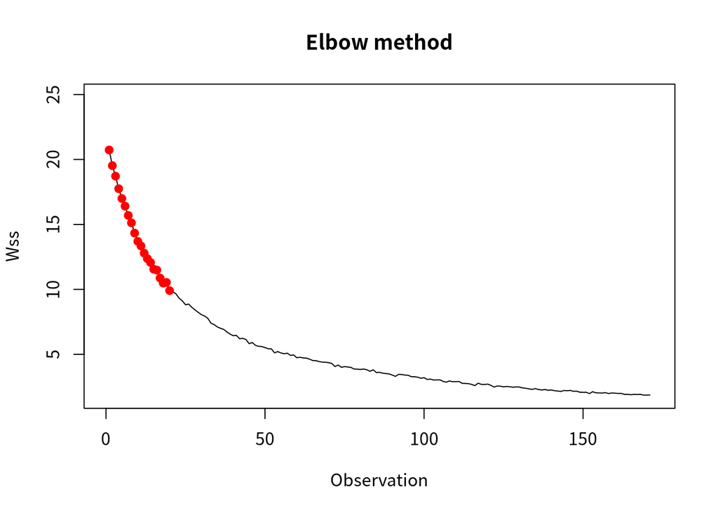

```r
# Line chart for Wss
plot(index$Wss, type = "l", xlab = "Observation", ylab = "Wss", main = "Elbow method",xlim = c(0, length(index$Wss) +1), ylim = c(min(index$Wss)*0.95, max(index$Wss)*1.2))


# 标记最大值
sorted <- sort(index$Wss, decreasing = TRUE)
top_three <- head(sorted,topnum)

for (i in 1:length(top_three)) {
  num <- which(index$Wss == top_three[i])
  #text(x = num, y = top_three[i]*1.05, labels = paste0("T", i, ": ", round(top_three[i],5)), offset = 1)
  for (n in num){
    points(x = n, y= top_three[i], col = "red", pch = 19)
  }
}
```

```r
# 将聚类结果添加到数据框中
#data2$cluster <- as.factor(kmeans_result$cluster)
```

Dunn:the higher the better (well-separated and compact)

CH:the higher the better (well-separated and compact)

S:The higher the better (well-separated and compact)

Entropy: the lower the better

Wss: the lower the better

weighted mean score = Dunn percentage + CH percentage + S percentage + entropy percentage + Wss percentage

```r
D <- index$Dunn
A <- index$`Average_Silhouette_Width`
CH <- index$`Calinski-Harabasz`
E <- index$Entropy
Wss <- index$Wss


#创建表
WS <- data.frame()

for (i in 1:length(D)){

  weight <- D[i]/max(D) + A[i]/max(A) + CH[i]/max(CH) + (1-E[i]/max(E)) + (1-Wss[i]/max(Wss))

  WS <- rbind(WS, c(i+Kmin -1 ,weight) )

}

colnames(WS) <- c("K-Num", "Weighted score")
datatable(WS)
```

|  | K-Num | Weighted score |
| --- | --- | --- |
| 1 | 10 | 2.883410533789243 |
| 2 | 11 | 2.787305540364271 |
| 3 | 12 | 2.677505709714694 |
| 4 | 13 | 2.794255085731228 |
| 5 | 14 | 2.635245058884104 |
| 6 | 15 | 2.641507551400159 |
| 7 | 16 | 2.52282513332404 |
| 8 | 17 | 2.623079782834451 |
| 9 | 18 | 2.650668434443275 |
| 10 | 19 | 2.539404075501586 |

[output cut: 161 more lines]

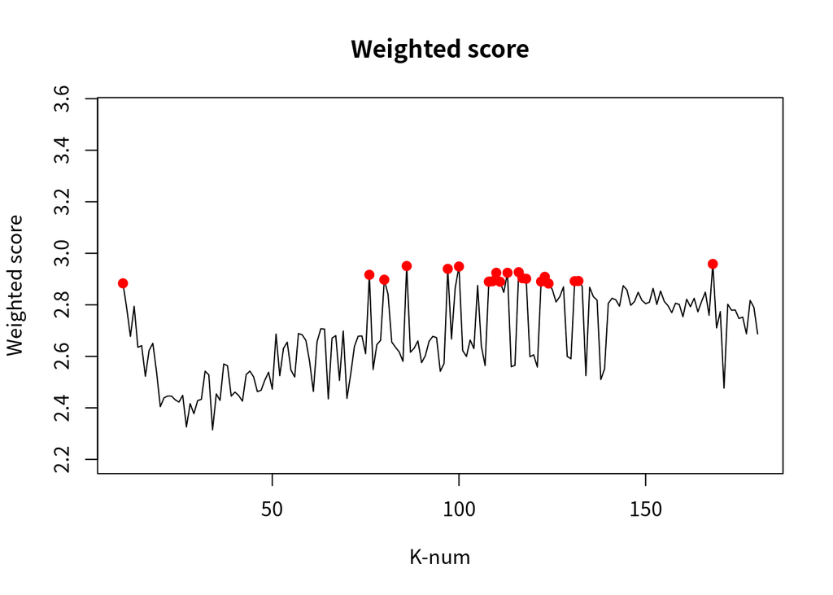

```r
# Line chart for WS
plot(x=WS$`K-Num` ,y=WS$`Weighted score`, type = "l", xlab = "K-num", ylab = "Weighted score", main = "Weighted score",xlim = c(Kmin, Kmin+length(WS$`Weighted score`)-1), ylim = c(min(WS$`Weighted score`)*0.95, max(WS$`Weighted score`)*1.2))

Best_K <- data.frame()

# 标记最大值
sorted <- sort(WS$`Weighted score`, decreasing = TRUE)
top_three <- head(sorted,topnum)

for (i in 1:length(WS$`Weighted score`)) {
  num <- which(WS$`Weighted score` == top_three[i])
  #text(x = num, y = top_three[i]*1.05, labels = paste0("T", i, ": ", round(top_three[i],5)), offset = 1)
  for (n in num){
    points(x = n +Kmin -1, y= top_three[i], col = "red", pch = 19)
    Best_K <- rbind(Best_K, c(i,n,top_three[i]) )


  }
}
```

```r
colnames(Best_K) <- c("Best_descend", "K-num","Weighted score")
datatable(Best_K)
```

|  | Best_descend | K-num | Weighted score |
| --- | --- | --- | --- |
| 1 | 1 | 159 | 2.958671047208762 |
| 2 | 2 | 77 | 2.950650706184302 |
| 3 | 3 | 91 | 2.948721806417309 |
| 4 | 4 | 88 | 2.939639914191166 |
| 5 | 5 | 107 | 2.926671542044188 |
| 6 | 6 | 104 | 2.924405557337648 |
| 7 | 7 | 101 | 2.924397951897935 |
| 8 | 8 | 67 | 2.916509100522284 |
| 9 | 9 | 114 | 2.908737690949705 |
| 10 | 10 | 108 | 2.903227046496211 |

[output cut: 10 more lines]

```r
alpha = 0.05

k_validated <- data.frame()

for (k in Best_K[,2]){
#Permutation法(排名百分数假设检验+特征放缩处理)
# 计算原始数据的聚类结果
orig_clusters <- kmeans(new_data, k)
data3<-data[1:972,c("X","Y","Z","virusPercent")]
orig_means <- tapply(new_data$mutation, orig_clusters$cluster, mean)
#这一步是为了计算原始数据中每个类的平均突变频率所处的百分位数。
#具体地，中包含原始数据中每个类突变频率的均值，那么 rank(orig_means) 返回原始数据中每个类的突变频率均值的排名。
#然后，通过除以 length(orig_means)，即原始数据被分成的类数，可以计算出每个类的均值的排名的比例。
#最后，乘以 100 并四舍五入到两位小数，即可得到排名。
orig_pcts <- round(rank(orig_means)/length(orig_means)*100, 2)

# 进行2000次突变概率重排并计算每次聚类结果
n_permutations <- 2000
perm_results <- matrix(NA, n_permutations, length(orig_means))
for (i in 1:n_permutations) {
  perm_data <- data3
  perm_data[,ncol(data3)] <- sample(data3[,ncol(data3)], replace=FALSE)
  mut_scale <- (perm_data[,ncol(data3)] - min(perm_data[,ncol(data3)])) / (max(perm_data[,ncol(data3)]) - min(perm_data[,ncol(data3)]))
  sta_scale <- data.frame(x = data2$x,y = data2$y,z = data2$z,mutation = mut_scale)
  perm_clusters <- kmeans(sta_scale, k)


  colnames(sta_scale) <- c("x", "y","z","mutation")

  perm_means <- tapply(sta_scale$mutation, perm_clusters$cluster, mean)
  perm_pcts <- round(rank(perm_means)/length(perm_means)*100, 2)
  #这行代码是用来计算每个聚类在重排结果中的百分位数。
  #具体来说，rank()函数计算了每个聚类均值在重排结果中的排名，
  #然后除以重排结果的总数，并乘以100，
  #得到了每个聚类在重排结果中的百分位数。
  #最后，round()函数将结果保留两位小数并四舍五入。
  #这个百分位数可以用来评估原始聚类结果中每个聚类的可能性是否显著高于随机聚类结果，
  #在第六步计算p值时会用到。
  perm_results[i,] <- perm_pcts
  #将每次重排得到的聚类结果的百分位数保存在perm_results矩阵中。
  #具体来说，perm_results矩阵的每一行都对应一次重排结果，
  #每一列对应一个聚类的百分位数。
  #在for循环中，第i次重排得到的三个聚类的百分位数保存在perm_pcts向量中，
  #然后将perm_pcts向量赋值给perm_results矩阵的第i行，
  #从而将这次重排的聚类结果存储在perm_results矩阵中。
}
# 计算每个聚类的p值
#检验原始数据中每个类的均值是否显著高原始数据的均值。
#具体来说，这个假设检验的零假设是：原始数据中每个类的均值与原始数据的均值相等，即不存在显著差异。
#备择假设是：原始数据中每个类的均值显著高于原始数据中的均值
p_values <- numeric(length(orig_means))
for (i in 1:length(orig_means)) {
  #具体来说，对于原始数据中的每个聚类，该代码计算了重排结果中百分位数高于该聚类百分位数的比例（即p值）。
  #如果p值很小，说明原始聚类结果中该聚类的百分位数显著高于随机聚类结果，
  #从而支持该聚类是显著的。反之，如果p值很大，说明该聚类的百分位数可能与随机聚类结果中的百分位数相似，从而不支持该聚类是显著的
  p_values[i] <- mean(perm_results[,i] >= orig_pcts[i])
}
# 输出结果
#cat("k-num", k, "\n")
#cat("原始聚类结果的均值：", orig_means, "\n")
#cat("原始聚类结果的百分位数：", orig_pcts, "\n")
#cat("p值：", p_values, "\n")
#cat("原始聚类结果中最高的平均突变频率：", max(orig_means), "\n")
#cat("对应的p值：", p_values[which.max(orig_means)], "\n")


#筛选p值，p值过小的点的k才选中
if (p_values[which.max(orig_means)]< alpha) {
  # 如果 condition 为 TRUE，则执行这里的代码
  cat("对应的p值过小，拒绝H0")
  k_validated <- rbind(k_validated,k)
} else {
  # 如果 condition 为 FALSE，则执行这里的代码
  cat("对应的p值过大，不拒绝H0")
}



#每次重排都会对原始数据进行打乱，破坏原始数据之间的任何关联性，
#然后重新进行聚类，得到每个聚类的平均突变频率。
#重排得到的聚类结果是随机的，由于在每次重排中使用了相同的聚类算法和距离度量方法，
#因此重排结果可以用来估计原始聚类结果中每个聚类的可能性是否显著高于随机聚类结果。
#如果原始聚类结果中的每个聚类的百分位数显著高于随机聚类结果，那么说明该聚类在原始数据中可能具有显著的生物学意义

#我们想要看到的是1/3越多越好，2/3和3/3越少越好。所以当1000次中1/3的次数超过950时，即2/3和3/3的次数小于50时，可说明在该聚类相对排名的普适性。
#首先对原始数据进行聚类，计算每个聚类的平均突变频率，
#并将每个聚类的平均突变频率转换为对应的百分位数。
#然后，使用突变概率重排法重复执行聚类过程，得到1000个随机聚类结果，
#并计算每个聚类在随机聚类结果中的百分位数。
#最后，对于原始数据中的每个聚类，计算其在随机聚类结果中的排名比原始聚类结果高的比例，高意思就是平均突变率小。排名越高，对应类的平均突变频率越小。
#从而得到对应的p值。如果p值小于设定的显著性水平（通常是0.05），则拒绝原假设，原始聚类结果中该聚类不是随机出现的，否则接受原假设（即该聚类可能是由随机性产生的，没有显著性）

#如果原始数据聚类后的平均突变那一类的p值小于0.05的话，print出该类里的点
# 如果最高平均突变频率的类的p值小于0.05，则显示该类的点
if (p_values[which.max(orig_means)] < 0.05) {
  cat("原始聚类结果中平均突变频率最高的聚类中的点：\n")
  cat(paste("行号\tX\tY\tZ\tvirusPercent\n"))
  selected_rows <- which(orig_clusters$cluster == which.max(orig_means))
  for (i in selected_rows) {
    cat(paste(i, "\t", new_data[i, "x"], "\t", new_data[i, "y"], "\t", new_data[i, "z"], "\t", data[i, "virusPercent"], "\n"))
  }

  # 可视化所有点（用蓝色表示）和突出显示的点（用红色表示）
  significant_points <- which(orig_clusters$cluster == which.max(orig_means))  # 提取p值小于0.05的聚类中的所有数据点的索引
  #print(significant_clusters)
  print(significant_points)
  # 提取p值小于0.05的聚类中的所有数据点的坐标
  significant_coordinates <- new_data[significant_points, c("x", "y", "z")]

  # 在三维点图中可视化所有数据点和p值小于0.05的聚类中的数据点
  fig <- plot_ly() %>%
    add_trace(data = new_data, x = ~x, y = ~y, z = ~z, type = "scatter3d", mode = "markers", name = "All Points") %>%
    add_trace(data = significant_coordinates, x = ~x, y = ~y, z = ~z, type = "scatter3d", mode = "markers", name = "Significant Clusters", marker = list(color = "red")) %>%
    layout(scene = list(xaxis = list(title = "X"), yaxis = list(title = "Y"), zaxis = list(title = "Z")))

  fig
}

#检验点的正确
cluster_data <- scale_vector[orig_clusters$cluster == which.max(orig_means), ]
print(cluster_data)




}
```

```
## 对应的p值过小，拒绝H0原始聚类结果中平均突变频率最高的聚类中的点：
## 行号   X   Y   Z   virusPercent
## 497   0.215224038941588   0.421575411738404   0.545984389442334   0.989406003007115
## [1] 497
##             X          Y          Z       V4
## 497 -1.077459 -0.3804004 -0.1140749 12.25599
## 对应的p值过小，拒绝H0原始聚类结果中平均突变频率最高的聚类中的点：
## 行号   X   Y   Z   virusPercent
## 42    0.114858961557664   0.938454823221301   0.718894423333676   0.399687750909765
## 106   0.233649525711433   0.962621498759728   0.801876861456301   0.715162514795645
## 143   0.216394158761857   0.930193439865433   0.652453271028037   0.349768146921745
## 497   0.215224038941588   0.421575411738404   0.545984389442334   0.989406003007115
## 518   0.102034448327509   0.552916502539098   0.472874088528294   0.477972908694149
## [1]  42 106 143 497 518
##             X          Y          Z        V4
```

[output cut: 1110 more lines]

```r
#筛选p值，p值过小的点的k才选中
if (length(k_validated) == 0) {
  temp <- 0
} else {
  # 如果 condition 为 FALSE，则执行这里的代码
  colnames(k_validated) <- c("K")

# 选取 K-num 与 K_validated 相同的行
Final_K <- Best_K[Best_K$`K-num` %in% k_validated$`K`, ]

datatable(Final_K)

}
```

|  | Best_descend | K-num | Weighted score |
| --- | --- | --- | --- |
| 1 | 1 | 159 | 2.958671047208762 |
| 2 | 2 | 77 | 2.950650706184302 |
| 3 | 3 | 91 | 2.948721806417309 |
| 4 | 4 | 88 | 2.939639914191166 |
| 5 | 5 | 107 | 2.926671542044188 |
| 6 | 6 | 104 | 2.924405557337648 |
| 7 | 7 | 101 | 2.924397951897935 |
| 8 | 8 | 67 | 2.916509100522284 |
| 9 | 9 | 114 | 2.908737690949705 |
| 10 | 10 | 108 | 2.903227046496211 |

[output cut: 9 more lines]

```r
alpha = 0.05

k_validated <- data.frame()

for (k in Best_K[,2]){

#Permutation法(排名百分数假设检验+标准化处理)
# 计算原始数据的聚类结果
orig_clusters <- kmeans(scale_vector, k)
data3<-data[1:972,c("X","Y","Z","virusPercent")]
orig_means <- tapply(scale_vector$V4, orig_clusters$cluster, mean)
#这一步是为了计算原始数据中每个类的平均突变频率所处的百分位数。
#具体地，中包含原始数据中每个类突变频率的均值，那么 rank(orig_means) 返回原始数据中每个类的突变频率均值的排名。
#然后，通过除以 length(orig_means)，即原始数据被分成的类数，可以计算出每个类的均值的排名的比例。
#最后，乘以 100 并四舍五入到两位小数，即可得到排名。
orig_pcts <- round(rank(orig_means)/length(orig_means)*100, 2)

# 进行2000次突变概率重排并计算每次聚类结果
n_permutations <- 2000
perm_results <- matrix(NA, n_permutations, length(orig_means))
x_scale <- scale(data3[,1])
y_scale <- scale(data3[,2])
z_scale <- scale(data3[,3])
for (i in 1:n_permutations) {
  perm_data <- data3
  perm_data[,ncol(data3)] <- sample(data3[,ncol(data3)], replace=FALSE)
  mut_scale <- scale(perm_data[,ncol(data3)])
  sta_scale <- data.frame(x = x_scale,y = y_scale,z = z_scale,mutation = mut_scale)
  perm_clusters <- kmeans(sta_scale, k)

  colnames(sta_scale) <- c("x", "y","z","mutation")

  perm_means <- tapply(sta_scale$mutation, perm_clusters$cluster, mean)
  perm_pcts <- round(rank(perm_means)/length(perm_means)*100, 2)
  #这行代码是用来计算每个聚类在重排结果中的百分位数。
  #具体来说，rank()函数计算了每个聚类均值在重排结果中的排名，
  #然后除以重排结果的总数，并乘以100，
  #得到了每个聚类在重排结果中的百分位数。
  #最后，round()函数将结果保留两位小数并四舍五入。
  #这个百分位数可以用来评估原始聚类结果中每个聚类的可能性是否显著高于随机聚类结果，
  #在第六步计算p值时会用到。
  perm_results[i,] <- perm_pcts
  #将每次重排得到的聚类结果的百分位数保存在perm_results矩阵中。
  #具体来说，perm_results矩阵的每一行都对应一次重排结果，
  #每一列对应一个聚类的百分位数。
  #在for循环中，第i次重排得到的三个聚类的百分位数保存在perm_pcts向量中，
  #然后将perm_pcts向量赋值给perm_results矩阵的第i行，
  #从而将这次重排的聚类结果存储在perm_results矩阵中。
}
# 计算每个聚类的p值
#检验原始数据中每个类的均值是否显著高原始数据的均值。
#具体来说，这个假设检验的零假设是：原始数据中每个类的均值与原始数据的均值相等，即不存在显著差异。
#备择假设是：原始数据中每个类的均值显著高于原始数据中的均值
p_values <- numeric(length(orig_means))
for (i in 1:length(orig_means)) {
  #具体来说，对于原始数据中的每个聚类，该代码计算了重排结果中百分位数高于该聚类百分位数的比例（即p值）。
  #如果p值很小，说明原始聚类结果中该聚类的百分位数显著高于随机聚类结果，
  #从而支持该聚类是显著的。反之，如果p值很大，说明该聚类的百分位数可能与随机聚类结果中的百分位数相似，从而不支持该聚类是显著的
  p_values[i] <- mean(perm_results[,i] >= orig_pcts[i])
}
# 输出结果
#cat("k-num", k, "\n")
#cat("原始聚类结果的均值：", orig_means, "\n")
#cat("原始聚类结果的百分位数：", orig_pcts, "\n")
#cat("p值：", p_values, "\n")
#cat("原始聚类结果中最高的平均突变频率：", max(orig_means), "\n")
#cat("对应的p值：", p_values[which.max(orig_means)], "\n")

#筛选p值，p值过小的点的k才选中
if (p_values[which.max(orig_means)]< alpha) {
  # 如果 condition 为 TRUE，则执行这里的代码
  cat("对应的p值过小，拒绝H0")
  k_validated <- rbind(k_validated,k)
} else {
  # 如果 condition 为 FALSE，则执行这里的代码
  cat("对应的p值过大，不拒绝H0")
}




#每次重排都会对原始数据进行打乱，破坏原始数据之间的任何关联性，
#然后重新进行聚类，得到每个聚类的平均突变频率。
#重排得到的聚类结果是随机的，由于在每次重排中使用了相同的聚类算法和距离度量方法，
#因此重排结果可以用来估计原始聚类结果中每个聚类的可能性是否显著高于随机聚类结果。
#如果原始聚类结果中的每个聚类的百分位数显著高于随机聚类结果，那么说明该聚类在原始数据中可能具有显著的生物学意义

#我们想要看到的是1/3越多越好，2/3和3/3越少越好。所以当1000次中1/3的次数超过950时，即2/3和3/3的次数小于50时，可说明在该聚类相对排名的普适性。
#首先对原始数据进行聚类，计算每个聚类的平均突变频率，
#并将每个聚类的平均突变频率转换为对应的百分位数。
#然后，使用突变概率重排法重复执行聚类过程，得到1000个随机聚类结果，
#并计算每个聚类在随机聚类结果中的百分位数。
#最后，对于原始数据中的每个聚类，计算其在随机聚类结果中的排名比原始聚类结果高的比例，高意思就是平均突变率小。排名越高，对应类的平均突变频率越小。
#从而得到对应的p值。如果p值小于设定的显著性水平（通常是0.05），则拒绝原假设，原始聚类结果中该聚类不是随机出现的，否则接受原假设（即该聚类可能是由随机性产生的，没有显著性）

#如果原始数据聚类后的平均突变那一类的p值小于0.05的话，print出该类里的点
# 如果最高平均突变频率的类的p值小于0.05，则显示该类的点
if (p_values[which.max(orig_means)] < 0.05) {
  cat("原始聚类结果中平均突变频率最高的聚类中的点：\n")
  cat(paste("行号\tX\tY\tZ\tvirusPercent\n"))
  selected_rows <- which(orig_clusters$cluster == which.max(orig_means))
  for (i in selected_rows) {
    cat(paste(i, "\t", scale_vector[i, "X"], "\t", scale_vector[i, "Y"], "\t", scale_vector[i, "Z"], "\t", scale_vector[i, "V4"], "\n"))
  }

  # 可视化所有点（用蓝色表示）和突出显示的点（用红色表示）
  significant_points <- which(orig_clusters$cluster == which.max(orig_means))  # 提取p值小于0.05的聚类中的所有数据点的索引
  #print(significant_clusters)
  print(significant_points)
  # 提取p值小于0.05的聚类中的所有数据点的坐标
  significant_coordinates <- scale_vector[significant_points, c("X", "Y", "Z")]

  # 在三维点图中可视化所有数据点和p值小于0.05的聚类中的数据点
  fig <- plot_ly() %>%
    add_trace(data = scale_vector, x = ~X, y = ~Y, z = ~Z, type = "scatter3d", mode = "markers", name = "All Points") %>%
    add_trace(data = significant_coordinates, x = ~X, y = ~Y, z = ~Z, type = "scatter3d", mode = "markers", name = "Significant Clusters", marker = list(color = "red")) %>%
    layout(scene = list(xaxis = list(title = "X"), yaxis = list(title = "Y"), zaxis = list(title = "Z")))

  fig
}

#检验点的正确
cluster_data <- scale_vector[orig_clusters$cluster == which.max(orig_means), ]
print(cluster_data)

}
```

```
## 对应的p值过小，拒绝H0原始聚类结果中平均突变频率最高的聚类中的点：
## 行号   X   Y   Z   virusPercent
## 106   -1.00205744693811   2.24575255915683    1.00448186517698    8.80698345774874
## 497   -1.07745933527812   -0.380400377346942      -0.114074933892292      12.2559863814267
## [1] 106 497
##             X          Y          Z        V4
## 106 -1.002057  2.2457526  1.0044819  8.806983
## 497 -1.077459 -0.3804004 -0.1140749 12.255986
```

```
## 对应的p值过小，拒绝H0原始聚类结果中平均突变频率最高的聚类中的点：
## 行号   X   Y   Z   virusPercent
## 106   -1.00205744693811   2.24575255915683    1.00448186517698    8.80698345774874
## 497   -1.07745933527812   -0.380400377346942      -0.114074933892292      12.2559863814267
## [1] 106 497
##             X          Y          Z        V4
## 106 -1.002057  2.2457526  1.0044819  8.806983
## 497 -1.077459 -0.3804004 -0.1140749 12.255986
## 对应的p值过小，拒绝H0原始聚类结果中平均突变频率最高的聚类中的点：
## 行号   X   Y   Z   virusPercent
## 106   -1.00205744693811   2.24575255915683    1.00448186517698    8.80698345774874
## 497   -1.07745933527812   -0.380400377346942      -0.114074933892292      12.2559863814267
## [1] 106 497
##             X          Y          Z        V4
## 106 -1.002057  2.2457526  1.0044819  8.806983
## 497 -1.077459 -0.3804004 -0.1140749 12.255986
## 对应的p值过小，拒绝H0原始聚类结果中平均突变频率最高的聚类中的点：
## 行号   X   Y   Z   virusPercent
## 106   -1.00205744693811   2.24575255915683    1.00448186517698    8.80698345774874
## 497   -1.07745933527812   -0.380400377346942      -0.114074933892292      12.2559863814267
## [1] 106 497
##             X          Y          Z        V4
## 106 -1.002057  2.2457526  1.0044819  8.806983
## 497 -1.077459 -0.3804004 -0.1140749 12.255986
## 对应的p值过小，拒绝H0原始聚类结果中平均突变频率最高的聚类中的点：
## 行号   X   Y   Z   virusPercent
## 106   -1.00205744693811   2.24575255915683    1.00448186517698    8.80698345774874
## 497   -1.07745933527812   -0.380400377346942      -0.114074933892292      12.2559863814267
## [1] 106 497
##             X          Y          Z        V4
## 106 -1.002057  2.2457526  1.0044819  8.806983
## 497 -1.077459 -0.3804004 -0.1140749 12.255986
## 对应的p值过小，拒绝H0原始聚类结果中平均突变频率最高的聚类中的点：
## 行号   X   Y   Z   virusPercent
## 106   -1.00205744693811   2.24575255915683    1.00448186517698    8.80698345774874
## 497   -1.07745933527812   -0.380400377346942      -0.114074933892292      12.2559863814267
## [1] 106 497
##             X          Y          Z        V4
## 106 -1.002057  2.2457526  1.0044819  8.806983
## 497 -1.077459 -0.3804004 -0.1140749 12.255986
## 对应的p值过小，拒绝H0原始聚类结果中平均突变频率最高的聚类中的点：
## 行号   X   Y   Z   virusPercent
## 106   -1.00205744693811   2.24575255915683    1.00448186517698    8.80698345774874
## 497   -1.07745933527812   -0.380400377346942      -0.114074933892292      12.2559863814267
## [1] 106 497
##             X          Y          Z        V4
## 106 -1.002057  2.2457526  1.0044819  8.806983
## 497 -1.077459 -0.3804004 -0.1140749 12.255986
```

```
## 对应的p值过小，拒绝H0原始聚类结果中平均突变频率最高的聚类中的点：
## 行号   X   Y   Z   virusPercent
## 106   -1.00205744693811   2.24575255915683    1.00448186517698    8.80698345774874
## 497   -1.07745933527812   -0.380400377346942      -0.114074933892292      12.2559863814267
## [1] 106 497
##             X          Y          Z        V4
## 106 -1.002057  2.2457526  1.0044819  8.806983
## 497 -1.077459 -0.3804004 -0.1140749 12.255986
## 对应的p值过小，拒绝H0原始聚类结果中平均突变频率最高的聚类中的点：
## 行号   X   Y   Z   virusPercent
## 106   -1.00205744693811   2.24575255915683    1.00448186517698    8.80698345774874
## 497   -1.07745933527812   -0.380400377346942      -0.114074933892292      12.2559863814267
## [1] 106 497
##             X          Y          Z        V4
## 106 -1.002057  2.2457526  1.0044819  8.806983
## 497 -1.077459 -0.3804004 -0.1140749 12.255986
## 对应的p值过小，拒绝H0原始聚类结果中平均突变频率最高的聚类中的点：
## 行号   X   Y   Z   virusPercent
## 497   -1.07745933527812   -0.380400377346942      -0.114074933892292      12.2559863814267
## [1] 497
##             X          Y          Z       V4
## 497 -1.077459 -0.3804004 -0.1140749 12.25599
## 对应的p值过小，拒绝H0原始聚类结果中平均突变频率最高的聚类中的点：
## 行号   X   Y   Z   virusPercent
## 106   -1.00205744693811   2.24575255915683    1.00448186517698    8.80698345774874
## 497   -1.07745933527812   -0.380400377346942      -0.114074933892292      12.2559863814267
## [1] 106 497
##             X          Y          Z        V4
## 106 -1.002057  2.2457526  1.0044819  8.806983
## 497 -1.077459 -0.3804004 -0.1140749 12.255986
```

```
## 对应的p值过小，拒绝H0原始聚类结果中平均突变频率最高的聚类中的点：
## 行号   X   Y   Z   virusPercent
## 106   -1.00205744693811   2.24575255915683    1.00448186517698    8.80698345774874
## 497   -1.07745933527812   -0.380400377346942      -0.114074933892292      12.2559863814267
## [1] 106 497
##             X          Y          Z        V4
## 106 -1.002057  2.2457526  1.0044819  8.806983
## 497 -1.077459 -0.3804004 -0.1140749 12.255986
## 对应的p值过小，拒绝H0原始聚类结果中平均突变频率最高的聚类中的点：
## 行号   X   Y   Z   virusPercent
## 106   -1.00205744693811   2.24575255915683    1.00448186517698    8.80698345774874
## 497   -1.07745933527812   -0.380400377346942      -0.114074933892292      12.2559863814267
## [1] 106 497
##             X          Y          Z        V4
## 106 -1.002057  2.2457526  1.0044819  8.806983
## 497 -1.077459 -0.3804004 -0.1140749 12.255986
```

```
## 对应的p值过小，拒绝H0原始聚类结果中平均突变频率最高的聚类中的点：
## 行号   X   Y   Z   virusPercent
## 106   -1.00205744693811   2.24575255915683    1.00448186517698    8.80698345774874
## 497   -1.07745933527812   -0.380400377346942      -0.114074933892292      12.2559863814267
## [1] 106 497
##             X          Y          Z        V4
## 106 -1.002057  2.2457526  1.0044819  8.806983
## 497 -1.077459 -0.3804004 -0.1140749 12.255986
## 对应的p值过小，拒绝H0原始聚类结果中平均突变频率最高的聚类中的点：
## 行号   X   Y   Z   virusPercent
## 106   -1.00205744693811   2.24575255915683    1.00448186517698    8.80698345774874
## 252   -0.947916209586433      -1.21463451297822   1.40368986540669    6.11555775718212
## 284   -0.5802282545059    -0.648746379969168      1.3778485266232     7.1436044057605
## 286   -0.357661800015408      -0.75245722673651   1.48368297818818    5.67964939702668
## 288   0.0265622169449418      -0.811831298951595      1.41115327052766    5.6799907156174
```

[output cut: 1070 more lines]

```r
#筛选p值，p值过小的点的k才选中
if (length(k_validated) == 0) {
  temp <- 0
} else {
  # 如果 condition 为 FALSE，则执行这里的代码
  colnames(k_validated) <- c("K")

# 选取 K-num 与 K_validated 相同的行
Final_K <- Best_K[Best_K$`K-num` %in% k_validated$`K`, ]

datatable(Final_K)

}
```

|  | Best_descend | K-num | Weighted score |
| --- | --- | --- | --- |
| 1 | 1 | 159 | 2.958671047208762 |
| 2 | 2 | 77 | 2.950650706184302 |
| 3 | 3 | 91 | 2.948721806417309 |
| 4 | 4 | 88 | 2.939639914191166 |
| 5 | 5 | 107 | 2.926671542044188 |
| 6 | 6 | 104 | 2.924405557337648 |
| 7 | 7 | 101 | 2.924397951897935 |
| 8 | 8 | 67 | 2.916509100522284 |
| 9 | 9 | 114 | 2.908737690949705 |
| 10 | 10 | 108 | 2.903227046496211 |

[output cut: 9 more lines]

##Determine parameter